# Analysis of How to Find the Best Players in Fantasy Football

## Introduction

Football season is among us. Many fans of the NFL play a game each year called fantasy football. This game consists of drafting real NFL players with your friends and creating you're own "fantasy team". Your team does well based on how you're players do in real life. Picking the best players can be contributed to many factors such as playing with other good players, having a good offensive, and having a good defense among other factors as well. Throughout this prject we will look at these different factors to try and determine which one can correlate to a higher scoring player.

For this project all data will be pulled from the [Pro Football Focus website](https://www.pff.com). We are going to use data from the years 2018-2022 form these categories: - Quarterbacks - Running Backs - Wide Receivers & Tight Ends - Offensive Lines

Using this data we will be able find expectations for how well an NFL player should perform based an certain statistics.

## Data Collection

### Imports

```python
import numpy as np
import pandas as pd
import seaborn as sns
import matplotlib.pyplot as plt
from sklearn.linear_model import LinearRegression
import statsmodels.formula.api as smf
```

First we will collect the data for all of the skill position players, wide receivers, tight ends, and running backs from the years 2018-2022

```python
sp_2018_df = pd.read_csv('./resources/stats/season2018/fantasy-stats-receiving.csv')
sp_2019_df = pd.read_csv('./resources/stats/season2019/fantasy-stats-receiving.csv')
sp_2020_df = pd.read_csv('./resources/stats/season2020/fantasy-stats-receiving.csv')
sp_2021_df = pd.read_csv('./resources/stats/season2021/fantasy-stats-receiving.csv')
sp_2022_df = pd.read_csv('./resources/stats/season2022/fantasy-stats-receiving.csv')
```

To consolidate the tables to only the higher scoring players we will drop all of the players who didn't play more than half of the games in a season. Also the data will be sorted by the total amount of fantasy points scored and we will only keep the stats that will be relevant to our analysis later on.

```python
sp_2018_df = sp_2018_df[sp_2018_df['games'] > 8].sort_values('fantasyPts', ascending=False)[['player', 'team', 'games', 'position', 'recTarg', 'recRec', 'rzRecTarg', 'ezRecTarg', 'rushCarries', 'rzRushCarries', 'i5RushCarries', 'fantasyPts']]
sp_2019_df = sp_2019_df[sp_2019_df['games'] > 8].sort_values('fantasyPts', ascending=False)[['player', 'team', 'games', 'position', 'recTarg', 'recRec', 'rzRecTarg', 'ezRecTarg', 'rushCarries', 'rzRushCarries', 'i5RushCarries', 'fantasyPts']]
sp_2020_df = sp_2020_df[sp_2020_df['games'] > 8].sort_values('fantasyPts', ascending=False)[['player', 'team', 'games', 'position', 'recTarg', 'recRec', 'rzRecTarg', 'ezRecTarg', 'rushCarries', 'rzRushCarries', 'i5RushCarries', 'fantasyPts']]
sp_2021_df = sp_2021_df[sp_2021_df['games'] > 8].sort_values('fantasyPts', ascending=False)[['player', 'team', 'games', 'position', 'recTarg', 'recRec', 'rzRecTarg', 'ezRecTarg', 'rushCarries', 'rzRushCarries', 'i5RushCarries', 'fantasyPts']]
sp_2022_df = sp_2022_df[sp_2022_df['games'] > 8].sort_values('fantasyPts', ascending=False)[['player', 'team', 'games', 'position', 'recTarg', 'recRec', 'rzRecTarg', 'ezRecTarg', 'rushCarries', 'rzRushCarries', 'i5RushCarries', 'fantasyPts']]
```

Next we will split the running backs from the tight ends and the wide receivers because the tight ends and wide receivers are considered pass catchers where as the running back line up in the backfield and get carries.

```python
pc_2018_df, rb_2018_df = [x for _, x in sp_2018_df.groupby(sp_2018_df['position'] == 'RB')]
pc_2019_df, rb_2019_df = [x for _, x in sp_2019_df.groupby(sp_2019_df['position'] == 'RB')]
pc_2020_df, rb_2020_df = [x for _, x in sp_2020_df.groupby(sp_2020_df['position'] == 'RB')]
pc_2021_df, rb_2021_df = [x for _, x in sp_2021_df.groupby(sp_2021_df['position'] == 'RB')]
pc_2022_df, rb_2022_df = [x for _, x in sp_2022_df.groupby(sp_2022_df['position'] == 'RB')]
```

Now that we have separated the pass catchers from the running backs. We will clean these tables so that we only keep the top scoring receiver and running back from each team.

```python
pc_2018_df = pc_2018_df.drop_duplicates(subset='team', keep='first').reset_index(drop=True)
pc_2019_df = pc_2019_df.drop_duplicates(subset='team', keep='first').reset_index(drop=True)
pc_2020_df = pc_2020_df.drop_duplicates(subset='team', keep='first').reset_index(drop=True)
pc_2021_df = pc_2021_df.drop_duplicates(subset='team', keep='first').reset_index(drop=True)
pc_2022_df = pc_2022_df.drop_duplicates(subset='team', keep='first').reset_index(drop=True)
```

```python
pc_2022_df
```

|  | player | team | games | position | recTarg | recRec | rzRecTarg | ezRecTarg | rushCarries | rzRushCarries | i5RushCarries | fantasyPts |
| --- | --- | --- | --- | --- | --- | --- | --- | --- | --- | --- | --- | --- |
| 0 | Justin Jefferson | MIN | 17 | WR | 176 | 128 | 48 | 14 | 4 | 1 | 1 | 365.3 |
| 1 | Tyreek Hill | MIA | 17 | WR | 167 | 119 | 27 | 5 | 7 | 2 | 1 | 341.2 |
| 2 | Davante Adams | LV | 17 | WR | 168 | 100 | 45 | 16 | 3 | 0 | 0 | 335.5 |
| 3 | Stefon Diggs | BUF | 16 | WR | 149 | 108 | 36 | 18 | 1 | 0 | 0 | 316.6 |
| 4 | Travis Kelce | KC | 17 | TE | 150 | 110 | 42 | 9 | 2 | 2 | 1 | 316.3 |
| 5 | A.J. Brown | PHI | 17 | WR | 137 | 88 | 39 | 10 | 0 | 0 | 0 | 303.6 |
| 6 | CeeDee Lamb | DAL | 17 | WR | 148 | 107 | 32 | 6 | 10 | 1 | 0 | 301.6 |
| 7 | Amon-Ra St. Brown | DET | 16 | WR | 139 | 106 | 27 | 5 | 9 | 4 | 1 | 267.6 |
| 8 | Amari Cooper | CLV | 17 | WR | 126 | 78 | 37 | 16 | 0 | 0 | 0 | 248.0 |
| 9 | Ja'Marr Chase | CIN | 12 | WR | 127 | 87 | 42 | 14 | 5 | 1 | 0 | 246.4 |
| 10 | Christian Kirk | JAX | 17 | WR | 123 | 84 | 28 | 7 | 5 | 0 | 0 | 243.9 |
| 11 | Tyler Lockett | SEA | 16 | WR | 109 | 84 | 27 | 10 | 0 | 0 | 0 | 241.3 |
| 12 | Brandon Aiyuk | SF | 17 | WR | 112 | 78 | 24 | 3 | 2 | 0 | 0 | 229.8 |
| 13 | Terry McLaurin | WAS | 17 | WR | 115 | 77 | 25 | 7 | 7 | 0 | 0 | 229.0 |
| 14 | Mike Evans | TB | 15 | WR | 123 | 77 | 33 | 10 | 0 | 0 | 0 | 226.3 |
| 15 | Michael Pittman Jr. | IND | 16 | WR | 139 | 99 | 22 | 8 | 3 | 0 | 0 | 218.5 |
| 16 | Garrett Wilson | NYJ | 17 | WR | 139 | 83 | 29 | 11 | 4 | 1 | 0 | 217.7 |
| 17 | Jerry Jeudy | DEN | 15 | WR | 100 | 68 | 21 | 9 | 3 | 0 | 0 | 205.3 |
| 18 | Cooper Kupp | LA | 9 | WR | 95 | 75 | 17 | 6 | 9 | 1 | 0 | 203.4 |
| 19 | Chris Olave | NO | 15 | WR | 114 | 72 | 27 | 5 | 0 | 0 | 0 | 200.4 |
| 20 | DJ Moore | CAR | 17 | WR | 109 | 63 | 25 | 11 | 10 | 1 | 0 | 199.1 |
| 21 | Mark Andrews | BLT | 15 | TE | 110 | 73 | 26 | 8 | 3 | 0 | 0 | 188.5 |
| 22 | Drake London | ATL | 17 | WR | 114 | 72 | 31 | 10 | 0 | 0 | 0 | 182.6 |
| 23 | Jakobi Meyers | NE | 14 | WR | 93 | 67 | 11 | 3 | 2 | 0 | 0 | 182.2 |
| 24 | Diontae Johnson | PIT | 17 | WR | 141 | 86 | 30 | 11 | 7 | 2 | 0 | 176.7 |
| 25 | Mike Williams | LAC | 13 | WR | 90 | 63 | 27 | 7 | 0 | 0 | 0 | 176.5 |
| 26 | Allen Lazard | GB | 15 | WR | 98 | 60 | 27 | 11 | 2 | 0 | 0 | 174.8 |
| 27 | Marquise Brown | ARZ | 12 | WR | 103 | 67 | 20 | 5 | 1 | 0 | 0 | 156.0 |
| 28 | Cole Kmet | CHI | 17 | TE | 69 | 50 | 14 | 6 | 2 | 0 | 0 | 147.3 |
| 29 | Brandin Cooks | HST | 13 | WR | 88 | 56 | 19 | 6 | 2 | 0 | 0 | 144.6 |
| 30 | Richie James | NYG | 15 | WR | 67 | 57 | 9 | 1 | 2 | 0 | 0 | 138.5 |
| 31 | Robert Woods | TEN | 17 | WR | 82 | 53 | 17 | 4 | 0 | 0 | 0 | 117.7 |

```python
rb_2018_df = rb_2018_df.drop_duplicates(subset='team', keep='first').reset_index(drop=True)
rb_2019_df = rb_2019_df.drop_duplicates(subset='team', keep='first').reset_index(drop=True)
rb_2020_df = rb_2020_df.drop_duplicates(subset='team', keep='first').reset_index(drop=True)
rb_2021_df = rb_2021_df.drop_duplicates(subset='team', keep='first').reset_index(drop=True)
rb_2022_df = rb_2022_df.drop_duplicates(subset='team', keep='first').reset_index(drop=True)
```

```python
rb_2022_df
```

|  | player | team | games | position | recTarg | recRec | rzRecTarg | ezRecTarg | rushCarries | rzRushCarries | i5RushCarries | fantasyPts |
| --- | --- | --- | --- | --- | --- | --- | --- | --- | --- | --- | --- | --- |
| 0 | Austin Ekeler | LAC | 17 | RB | 123 | 107 | 21 | 4 | 204 | 51 | 11 | 377.4 |
| 1 | Christian McCaffrey | SF | 17 | RB | 102 | 85 | 13 | 3 | 244 | 38 | 12 | 351.0 |
| 2 | Josh Jacobs | LV | 17 | RB | 61 | 53 | 3 | 0 | 340 | 43 | 12 | 330.3 |
| 3 | Derrick Henry | TEN | 16 | RB | 39 | 33 | 6 | 0 | 349 | 40 | 15 | 304.2 |
| 4 | Saquon Barkley | NYG | 16 | RB | 73 | 57 | 2 | 1 | 295 | 38 | 15 | 282.0 |
| 5 | Nick Chubb | CLV | 17 | RB | 33 | 27 | 1 | 1 | 302 | 41 | 12 | 281.4 |
| 6 | Aaron Jones | GB | 17 | RB | 72 | 59 | 12 | 2 | 214 | 31 | 3 | 253.0 |
| 7 | Rhamondre Stevenson | NE | 17 | RB | 87 | 69 | 7 | 1 | 210 | 32 | 12 | 251.2 |
| 8 | Tony Pollard | DAL | 16 | RB | 50 | 39 | 9 | 0 | 193 | 23 | 7 | 248.8 |
| 9 | Dalvin Cook | MIN | 17 | RB | 51 | 39 | 11 | 1 | 265 | 42 | 17 | 246.9 |
| 10 | Joe Mixon | CIN | 14 | RB | 70 | 60 | 13 | 4 | 210 | 39 | 17 | 239.6 |
| 11 | Leonard Fournette | TB | 16 | RB | 79 | 73 | 10 | 0 | 189 | 27 | 11 | 228.2 |
| 12 | Jamaal Williams | DET | 17 | RB | 16 | 12 | 2 | 0 | 262 | 58 | 33 | 227.9 |
| 13 | Najee Harris | PIT | 17 | RB | 53 | 41 | 9 | 2 | 272 | 42 | 12 | 227.7 |
| 14 | Miles Sanders | PHI | 17 | RB | 26 | 20 | 0 | 0 | 259 | 49 | 14 | 220.9 |
| 15 | Alvin Kamara | NO | 15 | RB | 71 | 57 | 11 | 2 | 223 | 25 | 4 | 219.7 |
| 16 | Travis Etienne Jr. | JAX | 17 | RB | 43 | 35 | 7 | 1 | 221 | 43 | 13 | 208.6 |
| 17 | Kenneth Walker III | SEA | 15 | RB | 34 | 27 | 0 | 0 | 228 | 51 | 10 | 202.5 |
| 18 | James Conner | ARZ | 13 | RB | 56 | 46 | 4 | 0 | 183 | 25 | 8 | 202.3 |
| 19 | Jerick McKinnon | KC | 17 | RB | 68 | 55 | 17 | 2 | 73 | 20 | 5 | 195.3 |
| 20 | Devin Singletary | BUF | 16 | RB | 47 | 38 | 7 | 0 | 177 | 35 | 10 | 183.9 |
| 21 | David Montgomery | CHI | 16 | RB | 39 | 34 | 3 | 0 | 201 | 34 | 4 | 181.7 |
| 22 | Dameon Pierce | HST | 13 | RB | 36 | 30 | 1 | 0 | 220 | 33 | 9 | 170.4 |
| 23 | Raheem Mostert | MIA | 16 | RB | 39 | 31 | 10 | 1 | 181 | 21 | 5 | 170.4 |
| 24 | Antonio Gibson | WAS | 15 | RB | 57 | 46 | 7 | 2 | 149 | 26 | 10 | 165.9 |
| 25 | Tyler Allgeier | ATL | 16 | RB | 17 | 16 | 0 | 0 | 210 | 39 | 10 | 157.4 |
| 26 | Jonathan Taylor | IND | 11 | RB | 34 | 28 | 3 | 0 | 192 | 32 | 9 | 152.4 |
| 27 | Latavius Murray | DEN | 13 | RB | 31 | 27 | 0 | 0 | 171 | 12 | 7 | 150.7 |
| 28 | Cam Akers | LA | 15 | RB | 17 | 13 | 3 | 0 | 188 | 28 | 8 | 145.3 |
| 29 | D'Onta Foreman | CAR | 17 | RB | 8 | 5 | 1 | 0 | 203 | 35 | 10 | 128.9 |
| 30 | Michael Carter | NYJ | 16 | RB | 47 | 41 | 5 | 1 | 114 | 20 | 4 | 128.0 |
| 31 | Kenyan Drake | BLT | 12 | RB | 24 | 17 | 5 | 1 | 109 | 20 | 4 | 104.1 |

These tables show the stats for the top pass catchers and running backs from each team for the years 2018-2022 ordered in descending order by the total amount of fantasy points that were scored that season. Next we will look at the stats for the quarterbacks during this same period.

```python
passcatcher_data = [pc_2018_df, pc_2019_df, pc_2020_df, pc_2021_df, pc_2022_df]
```

```python
runningback_data = [rb_2018_df, rb_2019_df, rb_2020_df, rb_2021_df, rb_2022_df]
```

```python
qb_2018_df = pd.read_csv('./resources/stats/season2018/fantasy-stats-passing.csv')
qb_2019_df = pd.read_csv('./resources/stats/season2019/fantasy-stats-passing.csv')
qb_2020_df = pd.read_csv('./resources/stats/season2020/fantasy-stats-passing.csv')
qb_2021_df = pd.read_csv('./resources/stats/season2021/fantasy-stats-passing.csv')
qb_2022_df = pd.read_csv('./resources/stats/season2022/fantasy-stats-passing.csv')
```

For this dataset we will only keep the quarterback who was to top performer for their team and sort the data by total fantasy points, keeping only the desired statistics that will be used in our analysis.

```python
qb_2018_df = qb_2018_df.sort_values('fantasyPts', ascending=False).drop_duplicates(subset='team', keep='first').reset_index(drop=True)[['player', 'team', 'games', 'att', 'comp', 'ezAtt', 'rushCarries', 'rzRushCarries', 'i5RushCarries', 'fantasyPts']]
qb_2019_df = qb_2019_df.sort_values('fantasyPts', ascending=False).drop_duplicates(subset='team', keep='first').reset_index(drop=True)[['player', 'team', 'games', 'att', 'comp', 'ezAtt', 'rushCarries', 'rzRushCarries', 'i5RushCarries', 'fantasyPts']]
qb_2020_df = qb_2020_df.sort_values('fantasyPts', ascending=False).drop_duplicates(subset='team', keep='first').reset_index(drop=True)[['player', 'team', 'games', 'att', 'comp', 'ezAtt', 'rushCarries', 'rzRushCarries', 'i5RushCarries', 'fantasyPts']]
qb_2021_df = qb_2021_df.sort_values('fantasyPts', ascending=False).drop_duplicates(subset='team', keep='first').reset_index(drop=True)[['player', 'team', 'games', 'att', 'comp', 'ezAtt', 'rushCarries', 'rzRushCarries', 'i5RushCarries', 'fantasyPts']]
qb_2022_df = qb_2022_df.sort_values('fantasyPts', ascending=False).drop_duplicates(subset='team', keep='first').reset_index(drop=True)[['player', 'team', 'games', 'att', 'comp', 'ezAtt', 'rushCarries', 'rzRushCarries', 'i5RushCarries', 'fantasyPts']]
```

```python
qb_2022_df
```

|  | player | team | games | att | comp | ezAtt | rushCarries | rzRushCarries | i5RushCarries | fantasyPts |
| --- | --- | --- | --- | --- | --- | --- | --- | --- | --- | --- |
| 0 | Patrick Mahomes | KC | 17 | 647 | 434 | 36 | 60 | 14 | 5 | 421.8 |
| 1 | Josh Allen | BUF | 16 | 567 | 359 | 45 | 124 | 27 | 12 | 415.5 |
| 2 | Jalen Hurts | PHI | 15 | 460 | 306 | 19 | 167 | 45 | 20 | 383.8 |
| 3 | Joe Burrow | CIN | 16 | 606 | 414 | 38 | 75 | 21 | 9 | 362.7 |
| 4 | Geno Smith | SEA | 17 | 572 | 399 | 45 | 68 | 7 | 0 | 322.9 |
| 5 | Trevor Lawrence | JAX | 17 | 584 | 387 | 40 | 61 | 15 | 6 | 315.6 |
| 6 | Justin Fields | CHI | 15 | 318 | 192 | 21 | 159 | 29 | 11 | 309.0 |
| 7 | Kirk Cousins | MIN | 17 | 643 | 424 | 36 | 30 | 7 | 3 | 305.6 |
| 8 | Daniel Jones | NYG | 16 | 472 | 317 | 11 | 121 | 25 | 9 | 295.5 |
| 9 | Justin Herbert | LAC | 17 | 699 | 477 | 44 | 54 | 7 | 2 | 294.4 |
| 10 | Jared Goff | DET | 17 | 587 | 382 | 34 | 29 | 5 | 0 | 293.8 |
| 11 | Tom Brady | TB | 17 | 733 | 490 | 36 | 29 | 11 | 2 | 285.0 |
| 12 | Aaron Rodgers | GB | 17 | 542 | 350 | 37 | 35 | 8 | 4 | 254.8 |
| 13 | Lamar Jackson | BLT | 12 | 326 | 203 | 28 | 111 | 19 | 4 | 245.2 |
| 14 | Tua Tagovailoa | MIA | 13 | 400 | 259 | 22 | 24 | 5 | 0 | 240.9 |
| 15 | Russell Wilson | DEN | 15 | 484 | 293 | 34 | 55 | 5 | 2 | 240.2 |
| 16 | Derek Carr | LV | 15 | 502 | 305 | 34 | 24 | 5 | 0 | 233.1 |
| 17 | Dak Prescott | DAL | 12 | 394 | 261 | 25 | 45 | 7 | 0 | 215.6 |
| 18 | Marcus Mariota | ATL | 13 | 300 | 184 | 19 | 84 | 19 | 4 | 207.6 |
| 19 | Kyler Murray | ARZ | 11 | 390 | 259 | 16 | 68 | 13 | 6 | 202.9 |
| 20 | Davis Mills | HST | 15 | 479 | 292 | 27 | 32 | 6 | 2 | 200.5 |
| 21 | Andy Dalton | NO | 14 | 378 | 252 | 16 | 30 | 6 | 2 | 183.2 |
| 22 | Jacoby Brissett | CLV | 16 | 369 | 236 | 30 | 49 | 11 | 2 | 182.6 |
| 23 | Mac Jones | NE | 14 | 442 | 288 | 17 | 47 | 9 | 1 | 181.1 |
| 24 | Matt Ryan | IND | 12 | 461 | 309 | 19 | 27 | 4 | 2 | 178.3 |
| 25 | Jimmy Garoppolo | SF | 11 | 307 | 206 | 16 | 23 | 5 | 4 | 172.7 |
| 26 | Ryan Tannehill | TEN | 12 | 325 | 212 | 18 | 34 | 7 | 4 | 169.2 |
| 27 | Kenny Pickett | PIT | 13 | 389 | 245 | 25 | 55 | 11 | 6 | 156.7 |
| 28 | Baker Mayfield | LA | 12 | 335 | 201 | 11 | 31 | 7 | 0 | 133.4 |
| 29 | Taylor Heinicke | WAS | 9 | 259 | 161 | 17 | 28 | 4 | 2 | 132.0 |
| 30 | Zach Wilson | NYJ | 9 | 242 | 132 | 10 | 28 | 8 | 3 | 100.7 |
| 31 | Sam Darnold | CAR | 6 | 140 | 82 | 10 | 26 | 6 | 3 | 93.3 |

```python
quarterback_data = [qb_2018_df, qb_2019_df, qb_2020_df, qb_2021_df, qb_2022_df]
```

Although offensive lines are not a part of fantasy football they are still a huge part of the game and impact every other position. Instead of using fantasy football stats we will be using Pro Football Focus' Offensive Line Grades from 2018-2022.

```python
ol_grades_df = pd.read_csv('./resources/stats/OLineGrades.csv')
```

```python
ol_grades_df
```

|  | team | 2022 | 2021 | 2020 | 2019 | 2018 |
| --- | --- | --- | --- | --- | --- | --- |
| 0 | ARZ | 71.6 | 67.8 | 73.7 | 77.4 | 55.7 |
| 1 | ATL | 73.2 | 52.4 | 62.4 | 64.2 | 78.2 |
| 2 | BLT | 79.6 | 69.7 | 74.2 | 87.0 | 77.1 |
| 3 | BUF | 63.0 | 68.9 | 71.9 | 71.8 | 71.6 |
| 4 | CAR | 72.8 | 53.9 | 67.2 | 67.1 | 76.6 |
| 5 | CHI | 68.2 | 66.8 | 59.4 | 69.2 | 83.8 |
| 6 | CIN | 58.6 | 56.9 | 58.3 | 63.7 | 66.8 |
| 7 | CLV | 73.4 | 70.3 | 86.5 | 71.3 | 85.8 |
| 8 | DAL | 68.4 | 80.0 | 59.1 | 78.3 | 73.1 |
| 9 | DEN | 66.9 | 71.4 | 62.5 | 74.3 | 62.7 |
| 10 | DET | 63.4 | 65.4 | 71.9 | 68.5 | 80.6 |
| 11 | GB | 77.6 | 73.8 | 80.0 | 80.8 | 88.5 |
| 12 | HST | 60.9 | 59.2 | 72.1 | 78.2 | 69.8 |
| 13 | IND | 62.9 | 59.2 | 71.6 | 75.1 | 79.8 |
| 14 | JAX | 73.5 | 70.1 | 64.7 | 67.0 | 65.0 |
| 15 | KC | 73.0 | 76.9 | 72.1 | 77.2 | 81.8 |
| 16 | LV | 73.0 | 62.6 | 67.2 | 74.0 | 62.2 |
| 17 | LAC | 66.7 | 67.4 | 54.5 | 59.9 | 59.7 |
| 18 | LA | 62.0 | 81.4 | 71.8 | 61.7 | 82.3 |
| 19 | MIA | 58.1 | 51.8 | 63.5 | 46.1 | 63.2 |
| 20 | MIN | 66.3 | 54.7 | 55.7 | 65.2 | 63.6 |
| 21 | NE | 72.5 | 71.2 | 67.7 | 74.1 | 80.3 |
| 22 | NO | 61.7 | 64.8 | 70.2 | 82.5 | 77.8 |
| 23 | NYG | 62.6 | 52.9 | 50.7 | 71.5 | 66.2 |
| 24 | NYJ | 59.2 | 64.4 | 53.4 | 62.4 | 70.9 |
| 25 | PHI | 83.2 | 77.6 | 67.5 | 81.1 | 78.8 |
| 26 | PIT | 69.5 | 68.3 | 73.9 | 79.3 | 87.3 |
| 27 | SF | 75.6 | 76.9 | 60.4 | 70.4 | 74.8 |
| 28 | SEA | 63.6 | 55.6 | 66.0 | 61.2 | 72.9 |
| 29 | TB | 76.9 | 81.3 | 69.6 | 76.6 | 70.7 |
| 30 | TEN | 52.4 | 53.3 | 56.7 | 74.9 | 79.0 |
| 31 | WAS | 61.7 | 78.3 | 76.6 | 67.3 | 71.1 |

## Exploratory Data Analysis

Now that we have all of our data we can start making transformations and visualizing some relationships. First to make sure our data is consistent we need to add a fantasy points per game column to the tables that do not already have it. Players can miss games for many reasons like an injury, illness, or even for having covid symptoms in some recent years. To standardize these discrepancies will calculate each players fantasy points per game in a column called 'fantasyPpg' and also sort by this new column

```python
def calcPointsPerGameAndSort(df):
    df['fantasyPpg'] = df['fantasyPts'] / df['games']
    df.sort_values('fantasyPpg', ascending=False, inplace=True)
    df.reset_index(drop=True, inplace=True)
    return df
```

```python
for df in quarterback_data:
    calcPointsPerGameAndSort(df)
for df in runningback_data:
    calcPointsPerGameAndSort(df)
for df in passcatcher_data:
    calcPointsPerGameAndSort(df)
```

```python
pc_2022_df.head(20)
```

|  | player | team | games | position | recTarg | recRec | rzRecTarg | ezRecTarg | rushCarries | rzRushCarries | i5RushCarries | fantasyPts | fantasyPpg |
| --- | --- | --- | --- | --- | --- | --- | --- | --- | --- | --- | --- | --- | --- |
| 0 | Cooper Kupp | LA | 9 | WR | 95 | 75 | 17 | 6 | 9 | 1 | 0 | 203.4 | 22.600000 |
| 1 | Justin Jefferson | MIN | 17 | WR | 176 | 128 | 48 | 14 | 4 | 1 | 1 | 365.3 | 21.488235 |
| 2 | Ja'Marr Chase | CIN | 12 | WR | 127 | 87 | 42 | 14 | 5 | 1 | 0 | 246.4 | 20.533333 |
| 3 | Tyreek Hill | MIA | 17 | WR | 167 | 119 | 27 | 5 | 7 | 2 | 1 | 341.2 | 20.070588 |
| 4 | Stefon Diggs | BUF | 16 | WR | 149 | 108 | 36 | 18 | 1 | 0 | 0 | 316.6 | 19.787500 |
| 5 | Davante Adams | LV | 17 | WR | 168 | 100 | 45 | 16 | 3 | 0 | 0 | 335.5 | 19.735294 |
| 6 | Travis Kelce | KC | 17 | TE | 150 | 110 | 42 | 9 | 2 | 2 | 1 | 316.3 | 18.605882 |
| 7 | A.J. Brown | PHI | 17 | WR | 137 | 88 | 39 | 10 | 0 | 0 | 0 | 303.6 | 17.858824 |
| 8 | CeeDee Lamb | DAL | 17 | WR | 148 | 107 | 32 | 6 | 10 | 1 | 0 | 301.6 | 17.741176 |
| 9 | Amon-Ra St. Brown | DET | 16 | WR | 139 | 106 | 27 | 5 | 9 | 4 | 1 | 267.6 | 16.725000 |
| 10 | Mike Evans | TB | 15 | WR | 123 | 77 | 33 | 10 | 0 | 0 | 0 | 226.3 | 15.086667 |
| 11 | Tyler Lockett | SEA | 16 | WR | 109 | 84 | 27 | 10 | 0 | 0 | 0 | 241.3 | 15.081250 |
| 12 | Amari Cooper | CLV | 17 | WR | 126 | 78 | 37 | 16 | 0 | 0 | 0 | 248.0 | 14.588235 |
| 13 | Christian Kirk | JAX | 17 | WR | 123 | 84 | 28 | 7 | 5 | 0 | 0 | 243.9 | 14.347059 |
| 14 | Jerry Jeudy | DEN | 15 | WR | 100 | 68 | 21 | 9 | 3 | 0 | 0 | 205.3 | 13.686667 |
| 15 | Michael Pittman Jr. | IND | 16 | WR | 139 | 99 | 22 | 8 | 3 | 0 | 0 | 218.5 | 13.656250 |
| 16 | Mike Williams | LAC | 13 | WR | 90 | 63 | 27 | 7 | 0 | 0 | 0 | 176.5 | 13.576923 |
| 17 | Brandon Aiyuk | SF | 17 | WR | 112 | 78 | 24 | 3 | 2 | 0 | 0 | 229.8 | 13.517647 |
| 18 | Terry McLaurin | WAS | 17 | WR | 115 | 77 | 25 | 7 | 7 | 0 | 0 | 229.0 | 13.470588 |
| 19 | Chris Olave | NO | 15 | WR | 114 | 72 | 27 | 5 | 0 | 0 | 0 | 200.4 | 13.360000 |

Now we can start visulaizing the data. The first relationship we are going to look at is how important is having a good quarterback on your team. Does having a higher scoring quarter back result in better productions for the other positions?

```python
qb_to_pc_2018 = pd.merge(qb_2018_df, pc_2018_df, on='team', how='inner')[['player_x','team', 'fantasyPpg_x', 'player_y', 'position', 'fantasyPpg_y']].sort_values('fantasyPpg_y', ascending=False).reset_index(drop=True)
qb_to_pc_2019 = pd.merge(qb_2019_df, pc_2019_df, on='team', how='inner')[['player_x','team', 'fantasyPpg_x', 'player_y', 'position', 'fantasyPpg_y']].sort_values('fantasyPpg_y', ascending=False).reset_index(drop=True)
qb_to_pc_2020 = pd.merge(qb_2020_df, pc_2020_df, on='team', how='inner')[['player_x','team', 'fantasyPpg_x', 'player_y', 'position', 'fantasyPpg_y']].sort_values('fantasyPpg_y', ascending=False).reset_index(drop=True)
qb_to_pc_2021 = pd.merge(qb_2021_df, pc_2021_df, on='team', how='inner')[['player_x','team', 'fantasyPpg_x', 'player_y', 'position', 'fantasyPpg_y']].sort_values('fantasyPpg_y', ascending=False).reset_index(drop=True)
qb_to_pc_2022 = pd.merge(qb_2022_df, pc_2022_df, on='team', how='inner')[['player_x','team', 'fantasyPpg_x', 'player_y', 'position', 'fantasyPpg_y']].sort_values('fantasyPpg_y', ascending=False).reset_index(drop=True)
```

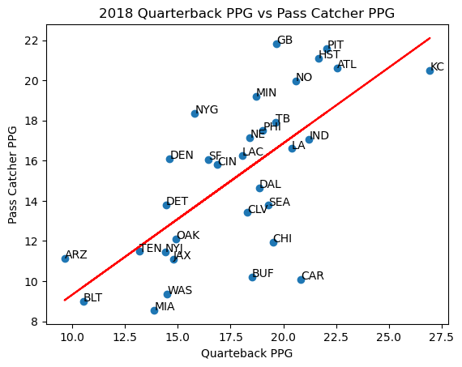

```python
plt.scatter(qb_to_pc_2018['fantasyPpg_x'], qb_to_pc_2018['fantasyPpg_y'])
slope, intercept = np.polyfit(qb_to_pc_2018['fantasyPpg_x'], qb_to_pc_2018['fantasyPpg_y'], 1)
plt.plot(qb_to_pc_2018['fantasyPpg_x'], intercept + slope * qb_to_pc_2018['fantasyPpg_x'], 'red')
plt.xlabel("Quarteback PPG")
plt.ylabel("Pass Catcher PPG")
plt.title("2018 Quarterback PPG vs Pass Catcher PPG")
for index in qb_to_pc_2018.index:
    row = qb_to_pc_2018.loc[index]
    plt.text(row['fantasyPpg_x'], row['fantasyPpg_y'], row['team'])
plt.show()
```

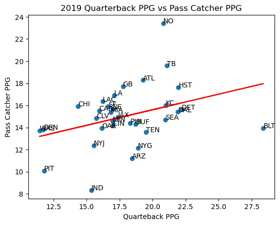

```python
plt.scatter(qb_to_pc_2019['fantasyPpg_x'], qb_to_pc_2019['fantasyPpg_y'])
slope, intercept = np.polyfit(qb_to_pc_2019['fantasyPpg_x'], qb_to_pc_2019['fantasyPpg_y'], 1)
plt.plot(qb_to_pc_2019['fantasyPpg_x'], intercept + slope * qb_to_pc_2019['fantasyPpg_x'], 'red')
plt.xlabel("Quarteback PPG")
plt.ylabel("Pass Catcher PPG")
plt.title("2019 Quarterback PPG vs Pass Catcher PPG")
for index in qb_to_pc_2019.index:
    row = qb_to_pc_2019.loc[index]
    plt.text(row['fantasyPpg_x'], row['fantasyPpg_y'], row['team'])
plt.show()
```

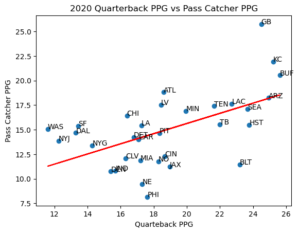

```python
plt.scatter(qb_to_pc_2020['fantasyPpg_x'], qb_to_pc_2020['fantasyPpg_y'])
slope, intercept = np.polyfit(qb_to_pc_2020['fantasyPpg_x'], qb_to_pc_2020['fantasyPpg_y'], 1)
plt.plot(qb_to_pc_2020['fantasyPpg_x'], intercept + slope * qb_to_pc_2020['fantasyPpg_x'], 'red')
plt.xlabel("Quarteback PPG")
plt.ylabel("Pass Catcher PPG")
plt.title("2020 Quarterback PPG vs Pass Catcher PPG")
for index in qb_to_pc_2020.index:
    row = qb_to_pc_2020.loc[index]
    plt.text(row['fantasyPpg_x'], row['fantasyPpg_y'], row['team'])
plt.show()
```

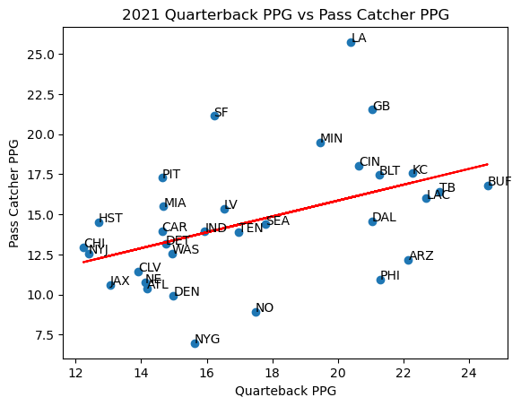

```python
plt.scatter(qb_to_pc_2021['fantasyPpg_x'], qb_to_pc_2021['fantasyPpg_y'])
slope, intercept = np.polyfit(qb_to_pc_2021['fantasyPpg_x'], qb_to_pc_2021['fantasyPpg_y'], 1)
plt.plot(qb_to_pc_2021['fantasyPpg_x'], intercept + slope * qb_to_pc_2021['fantasyPpg_x'], 'red')
plt.xlabel("Quarteback PPG")
plt.ylabel("Pass Catcher PPG")
plt.title("2021 Quarterback PPG vs Pass Catcher PPG")
for index in qb_to_pc_2021.index:
    row = qb_to_pc_2021.loc[index]
    plt.text(row['fantasyPpg_x'], row['fantasyPpg_y'], row['team'])
plt.show()
```

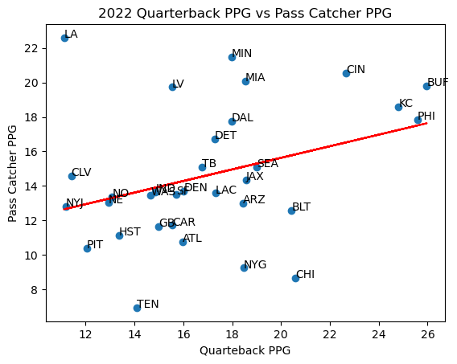

```python
plt.scatter(qb_to_pc_2022['fantasyPpg_x'], qb_to_pc_2022['fantasyPpg_y'])
slope, intercept = np.polyfit(qb_to_pc_2022['fantasyPpg_x'], qb_to_pc_2022['fantasyPpg_y'], 1)
plt.plot(qb_to_pc_2022['fantasyPpg_x'], intercept + slope * qb_to_pc_2022['fantasyPpg_x'], 'red')
plt.xlabel("Quarteback PPG")
plt.ylabel("Pass Catcher PPG")
plt.title("2022 Quarterback PPG vs Pass Catcher PPG")
for index in qb_to_pc_2022.index:
    row = qb_to_pc_2022.loc[index]
    plt.text(row['fantasyPpg_x'], row['fantasyPpg_y'], row['team'])
plt.show()
```

The plots above show the relationship between a teams top pass catcher in fantasy points per game in relation to their quarterbacks fantasy points per game. The red lines represent the data's line of best fit and as you can see generally the the more points a quartback scores the more points their pass catchers will score. Now we will look at if the same holds true for the quarterback to runningback relationship.

```python
qb_to_rb_2018 = pd.merge(qb_2018_df, rb_2018_df, on='team', how='inner')[['player_x','team', 'fantasyPpg_x', 'player_y', 'fantasyPpg_y']].sort_values('fantasyPpg_y', ascending=False).reset_index(drop=True)
qb_to_rb_2019 = pd.merge(qb_2019_df, rb_2019_df, on='team', how='inner')[['player_x','team', 'fantasyPpg_x', 'player_y', 'fantasyPpg_y']].sort_values('fantasyPpg_y', ascending=False).reset_index(drop=True)
qb_to_rb_2020 = pd.merge(qb_2020_df, rb_2020_df, on='team', how='inner')[['player_x','team', 'fantasyPpg_x', 'player_y', 'fantasyPpg_y']].sort_values('fantasyPpg_y', ascending=False).reset_index(drop=True)
qb_to_rb_2021 = pd.merge(qb_2021_df, rb_2021_df, on='team', how='inner')[['player_x','team', 'fantasyPpg_x', 'player_y', 'fantasyPpg_y']].sort_values('fantasyPpg_y', ascending=False).reset_index(drop=True)
qb_to_rb_2022 = pd.merge(qb_2022_df, rb_2022_df, on='team', how='inner')[['player_x','team', 'fantasyPpg_x', 'player_y', 'fantasyPpg_y']].sort_values('fantasyPpg_y', ascending=False).reset_index(drop=True)
```

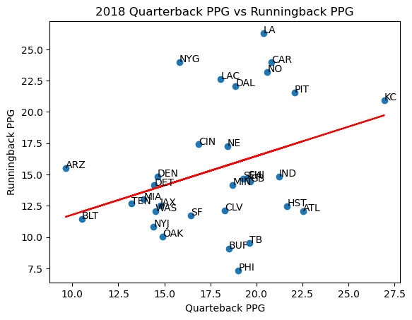

```python
plt.scatter(qb_to_rb_2018['fantasyPpg_x'], qb_to_rb_2018['fantasyPpg_y'])
slope, intercept = np.polyfit(qb_to_rb_2018['fantasyPpg_x'], qb_to_rb_2018['fantasyPpg_y'], 1)
plt.plot(qb_to_rb_2018['fantasyPpg_x'], intercept + slope * qb_to_rb_2018['fantasyPpg_x'], 'red')
plt.xlabel("Quarteback PPG")
plt.ylabel("Runningback PPG")
plt.title("2018 Quarterback PPG vs Runningback PPG")
for index in qb_to_rb_2018.index:
    row = qb_to_rb_2018.loc[index]
    plt.text(row['fantasyPpg_x'], row['fantasyPpg_y'], row['team'])
plt.show()
```

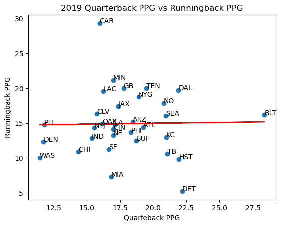

```python
plt.scatter(qb_to_rb_2019['fantasyPpg_x'], qb_to_rb_2019['fantasyPpg_y'])
slope, intercept = np.polyfit(qb_to_rb_2019['fantasyPpg_x'], qb_to_rb_2019['fantasyPpg_y'], 1)
plt.plot(qb_to_rb_2019['fantasyPpg_x'], intercept + slope * qb_to_rb_2019['fantasyPpg_x'], 'red')
plt.xlabel("Quarteback PPG")
plt.ylabel("Runningback PPG")
plt.title("2019 Quarterback PPG vs Runningback PPG")
for index in qb_to_rb_2019.index:
    row = qb_to_rb_2019.loc[index]
    plt.text(row['fantasyPpg_x'], row['fantasyPpg_y'], row['team'])
plt.show()
```

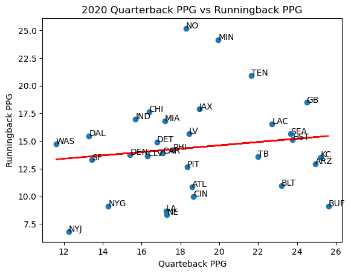

```python
plt.scatter(qb_to_rb_2020['fantasyPpg_x'], qb_to_rb_2020['fantasyPpg_y'])
slope, intercept = np.polyfit(qb_to_rb_2020['fantasyPpg_x'], qb_to_rb_2020['fantasyPpg_y'], 1)
plt.plot(qb_to_rb_2020['fantasyPpg_x'], intercept + slope * qb_to_rb_2020['fantasyPpg_x'], 'red')
plt.xlabel("Quarteback PPG")
plt.ylabel("Runningback PPG")
plt.title("2020 Quarterback PPG vs Runningback PPG")
for index in qb_to_rb_2020.index:
    row = qb_to_rb_2020.loc[index]
    plt.text(row['fantasyPpg_x'], row['fantasyPpg_y'], row['team'])
plt.show()
```

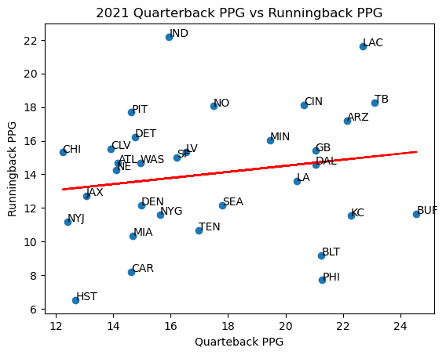

```python
plt.scatter(qb_to_rb_2021['fantasyPpg_x'], qb_to_rb_2021['fantasyPpg_y'])
slope, intercept = np.polyfit(qb_to_rb_2021['fantasyPpg_x'], qb_to_rb_2021['fantasyPpg_y'], 1)
plt.plot(qb_to_rb_2021['fantasyPpg_x'], intercept + slope * qb_to_rb_2021['fantasyPpg_x'], 'red')
plt.xlabel("Quarteback PPG")
plt.ylabel("Runningback PPG")
plt.title("2021 Quarterback PPG vs Runningback PPG")
for index in qb_to_rb_2021.index:
    row = qb_to_rb_2021.loc[index]
    plt.text(row['fantasyPpg_x'], row['fantasyPpg_y'], row['team'])
plt.show()
```

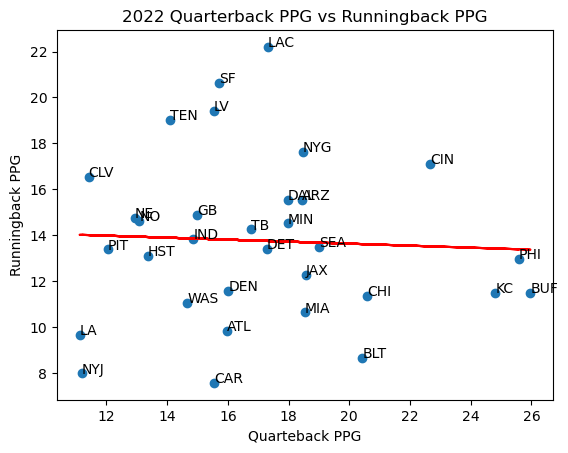

```python
plt.scatter(qb_to_rb_2022['fantasyPpg_x'], qb_to_rb_2022['fantasyPpg_y'])
slope, intercept = np.polyfit(qb_to_rb_2022['fantasyPpg_x'], qb_to_rb_2022['fantasyPpg_y'], 1)
plt.plot(qb_to_rb_2022['fantasyPpg_x'], intercept + slope * qb_to_rb_2022['fantasyPpg_x'], 'red')
plt.xlabel("Quarteback PPG")
plt.ylabel("Runningback PPG")
plt.title("2022 Quarterback PPG vs Runningback PPG")
for index in qb_to_rb_2022.index:
    row = qb_to_rb_2022.loc[index]
    plt.text(row['fantasyPpg_x'], row['fantasyPpg_y'], row['team'])
plt.show()
```

```python
qb_to_rb_2022 = qb_to_rb_2022.drop([19, 23, 24, 28, 29])
```

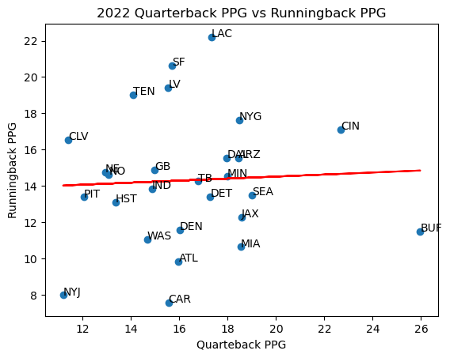

```python
plt.scatter(qb_to_rb_2022['fantasyPpg_x'], qb_to_rb_2022['fantasyPpg_y'])
slope, intercept = np.polyfit(qb_to_rb_2022['fantasyPpg_x'], qb_to_rb_2022['fantasyPpg_y'], 1)
plt.plot(qb_to_rb_2022['fantasyPpg_x'], intercept + slope * qb_to_rb_2022['fantasyPpg_x'], 'red')
plt.xlabel("Quarteback PPG")
plt.ylabel("Runningback PPG")
plt.title("2022 Quarterback PPG vs Runningback PPG")
for index in qb_to_rb_2022.index:
    row = qb_to_rb_2022.loc[index]
    plt.text(row['fantasyPpg_x'], row['fantasyPpg_y'], row['team'])
plt.show()
```

Taking out a few of these outliers show that for most teams that year there was still a small positive relationship between having a good quarterback and a good runningback.

Next lets look at if offensive line impacts a quarterbacks performance. For this we will look at the offensive line grades according to Pro Football Focus and the quarterback fantasy production.

First since the Oakland Raiders relocated to Las Vegas in 2020 we need change the team label of 'OAK' in the 2018 and 2019 of the quarterback data to 'LV' so the data is consistent.

```python
qb_2018_df.at[22, 'team'] = 'LV'
qb_2019_df.at[23, 'team'] = 'LV'
```

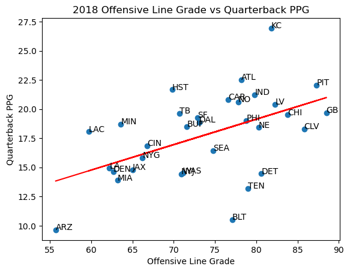

```python
ol_grades_2018 = ol_grades_df.sort_values('team').reset_index(drop=True)['2018']
qb_2018_by_team = qb_2018_df.sort_values('team').reset_index(drop=True)['fantasyPpg']
plt.scatter(ol_grades_2018, qb_2018_by_team)
slope, intercept = np.polyfit(ol_grades_2018, qb_2018_by_team, 1)
plt.plot(ol_grades_2018, intercept + slope * ol_grades_2018, 'red')
plt.xlabel("Offensive Line Grade")
plt.ylabel("Quarterback PPG")
plt.title("2018 Offensive Line Grade vs Quarterback PPG")
for index in ol_grades_2018.index:
    plt.text(ol_grades_2018.loc[index], qb_2018_by_team.loc[index], ol_grades_df.sort_values('team').loc[index]['team'])
plt.show()
```

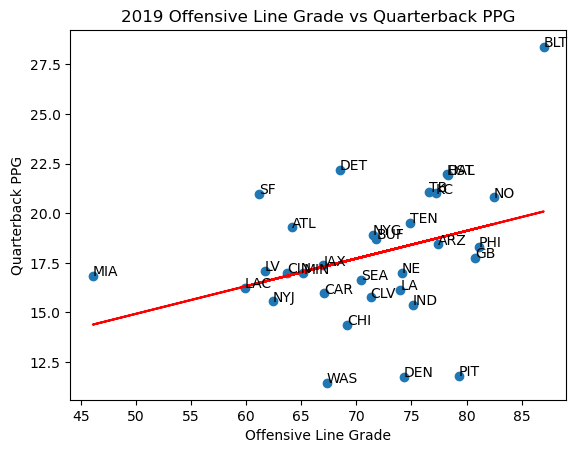

```python
ol_grades_2019 = ol_grades_df.sort_values('team').reset_index(drop=True)['2019']
qb_2019_by_team = qb_2019_df.sort_values('team').reset_index(drop=True)['fantasyPpg']
plt.scatter(ol_grades_2019, qb_2019_by_team)
slope, intercept = np.polyfit(ol_grades_2019, qb_2019_by_team, 1)
plt.plot(ol_grades_2019, intercept + slope * ol_grades_2019, 'red')
plt.xlabel("Offensive Line Grade")
plt.ylabel("Quarterback PPG")
plt.title("2019 Offensive Line Grade vs Quarterback PPG")
for index in ol_grades_2019.index:
    plt.text(ol_grades_2019.loc[index], qb_2019_by_team.loc[index], ol_grades_df.sort_values('team').loc[index]['team'])
plt.show()
```

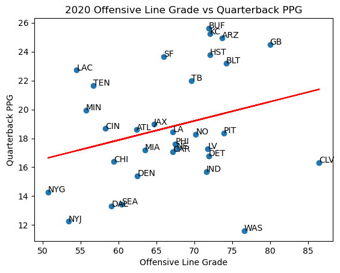

```python
ol_grades_2020 = ol_grades_df.sort_values('team').reset_index(drop=True)['2020']
qb_2020_by_team = qb_2020_df.sort_values('team').reset_index(drop=True)['fantasyPpg']
plt.scatter(ol_grades_2020, qb_2020_by_team)
slope, intercept = np.polyfit(ol_grades_2020, qb_2020_by_team, 1)
plt.plot(ol_grades_2020, intercept + slope * ol_grades_2020, 'red')
plt.xlabel("Offensive Line Grade")
plt.ylabel("Quarterback PPG")
plt.title("2020 Offensive Line Grade vs Quarterback PPG")
for index in ol_grades_2020.index:
    plt.text(ol_grades_2020.loc[index], qb_2020_by_team.loc[index], ol_grades_df.sort_values('team').loc[index]['team'])
plt.show()
```

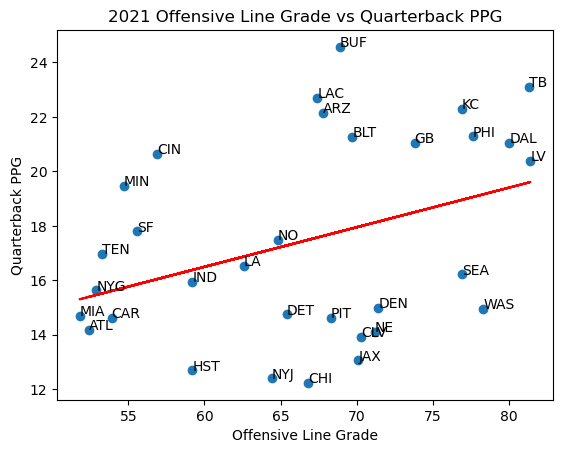

```python
ol_grades_2021 = ol_grades_df.sort_values('team').reset_index(drop=True)['2021']
qb_2021_by_team = qb_2021_df.sort_values('team').reset_index(drop=True)['fantasyPpg']
plt.scatter(ol_grades_2021, qb_2021_by_team)
slope, intercept = np.polyfit(ol_grades_2021, qb_2021_by_team, 1)
plt.plot(ol_grades_2021, intercept + slope * ol_grades_2021, 'red')
plt.xlabel("Offensive Line Grade")
plt.ylabel("Quarterback PPG")
plt.title("2021 Offensive Line Grade vs Quarterback PPG")
for index in ol_grades_2021.index:
    plt.text(ol_grades_2021.loc[index], qb_2021_by_team.loc[index], ol_grades_df.sort_values('team').loc[index]['team'])
plt.show()
```

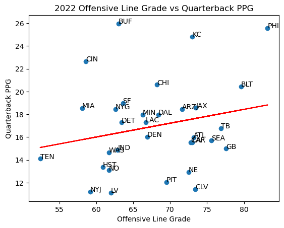

```python
ol_grades_2022 = ol_grades_df.sort_values('team').reset_index(drop=True)['2022']
qb_2022_by_team = qb_2022_df.sort_values('team').reset_index(drop=True)['fantasyPpg']
plt.scatter(ol_grades_2022, qb_2022_by_team)
slope, intercept = np.polyfit(ol_grades_2022, qb_2022_by_team, 1)
plt.plot(ol_grades_2022, intercept + slope * ol_grades_2022, 'red')
plt.xlabel("Offensive Line Grade")
plt.ylabel("Quarterback PPG")
plt.title("2022 Offensive Line Grade vs Quarterback PPG")
for index in ol_grades_2022.index:
    plt.text(ol_grades_2022.loc[index], qb_2022_by_team.loc[index], ol_grades_df.sort_values('team').loc[index]['team'])
plt.show()
```

As you can see in the plots above having a better offensive line seems to correlate to having better production at that teams quarterback position.

For the next analysis we are going to look how a quarterbacks running ability affects their fantasy production. First we will have to calculate the rush carries per game for each quarterback.

```python
def calcRushPerGame(df):
    df['rushCarriesPg'] = df['rushCarries'] / df['games']
    return df
```

```python
qb_2018_df
```

|  | player | team | games | att | comp | ezAtt | rushCarries | rzRushCarries | i5RushCarries | fantasyPts | fantasyPpg |
| --- | --- | --- | --- | --- | --- | --- | --- | --- | --- | --- | --- |
| 0 | Patrick Mahomes | KC | 16 | 580 | 383 | 43 | 60 | 15 | 6 | 431.1 | 26.943750 |
| 1 | Matt Ryan | ATL | 16 | 608 | 422 | 34 | 34 | 8 | 2 | 360.5 | 22.531250 |
| 2 | Ben Roethlisberger | PIT | 16 | 675 | 452 | 50 | 31 | 5 | 3 | 353.0 | 22.062500 |
| 3 | Deshaun Watson | HST | 16 | 505 | 345 | 47 | 100 | 22 | 9 | 346.6 | 21.662500 |
| 4 | Andrew Luck | IND | 16 | 639 | 430 | 48 | 46 | 7 | 1 | 339.5 | 21.218750 |
| 5 | Cam Newton | CAR | 14 | 471 | 320 | 27 | 101 | 16 | 5 | 291.6 | 20.828571 |
| 6 | Drew Brees | NO | 15 | 489 | 364 | 29 | 31 | 6 | 4 | 308.9 | 20.593333 |
| 7 | Jared Goff | LA | 16 | 561 | 364 | 40 | 42 | 7 | 2 | 326.3 | 20.393750 |
| 8 | Aaron Rodgers | GB | 16 | 597 | 372 | 41 | 43 | 8 | 2 | 314.6 | 19.662500 |
| 9 | Jameis Winston | TB | 11 | 378 | 244 | 30 | 49 | 8 | 0 | 215.8 | 19.618182 |
| 10 | Mitch Trubisky | CHI | 14 | 434 | 289 | 32 | 68 | 6 | 2 | 273.0 | 19.500000 |
| 11 | Russell Wilson | SEA | 16 | 427 | 280 | 48 | 67 | 8 | 1 | 308.5 | 19.281250 |
| 12 | Carson Wentz | PHI | 11 | 401 | 279 | 25 | 34 | 5 | 3 | 209.3 | 19.027273 |
| 13 | Dak Prescott | DAL | 16 | 526 | 356 | 34 | 75 | 19 | 9 | 301.9 | 18.868750 |
| 14 | Kirk Cousins | MIN | 16 | 606 | 425 | 39 | 44 | 6 | 1 | 299.4 | 18.712500 |
| 15 | Josh Allen | BUF | 12 | 320 | 169 | 16 | 89 | 21 | 5 | 222.1 | 18.508333 |
| 16 | Tom Brady | NE | 16 | 570 | 375 | 34 | 23 | 6 | 2 | 294.7 | 18.418750 |
| 17 | Baker Mayfield | CLV | 14 | 486 | 310 | 32 | 39 | 7 | 4 | 256.1 | 18.292857 |
| 18 | Philip Rivers | LAC | 16 | 508 | 347 | 41 | 18 | 9 | 4 | 289.0 | 18.062500 |
| 19 | Andy Dalton | CIN | 11 | 365 | 226 | 30 | 16 | 1 | 0 | 185.5 | 16.863636 |
| 20 | Nick Mullens | SF | 8 | 274 | 176 | 14 | 18 | 2 | 1 | 131.5 | 16.437500 |
| 21 | Eli Manning | NYG | 16 | 576 | 380 | 40 | 15 | 6 | 3 | 253.0 | 15.812500 |
| 22 | Derek Carr | LV | 16 | 553 | 381 | 25 | 24 | 5 | 2 | 238.7 | 14.918750 |
| 23 | Blake Bortles | JAX | 13 | 403 | 243 | 18 | 58 | 5 | 0 | 192.2 | 14.784615 |
| 24 | Case Keenum | DEN | 16 | 586 | 365 | 31 | 26 | 2 | 2 | 233.9 | 14.618750 |
| 25 | Alex Smith | WAS | 10 | 328 | 205 | 10 | 41 | 10 | 1 | 145.0 | 14.500000 |
| 26 | Matthew Stafford | DET | 16 | 555 | 367 | 38 | 25 | 3 | 0 | 231.2 | 14.450000 |
| 27 | Sam Darnold | NYJ | 13 | 414 | 239 | 27 | 44 | 11 | 3 | 187.4 | 14.415385 |
| 28 | Ryan Tannehill | MIA | 11 | 274 | 176 | 13 | 32 | 4 | 0 | 152.7 | 13.881818 |
| 29 | Marcus Mariota | TEN | 14 | 331 | 228 | 21 | 64 | 12 | 6 | 184.8 | 13.200000 |
| 30 | Lamar Jackson | BLT | 16 | 170 | 99 | 7 | 148 | 38 | 6 | 168.3 | 10.518750 |
| 31 | Josh Rosen | ARZ | 14 | 393 | 217 | 22 | 23 | 0 | 0 | 134.9 | 9.635714 |

```python
for df in quarterback_data:
    calcRushPerGame(df)
```

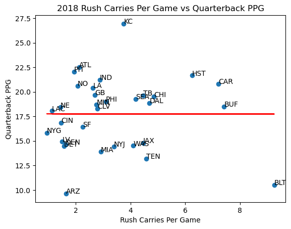

```python
plt.scatter(qb_2018_df['rushCarriesPg'], qb_2018_df['fantasyPpg'])
slope, intercept = np.polyfit(qb_2018_df['rushCarriesPg'], qb_2018_df['fantasyPpg'], 1)
plt.plot(qb_2018_df['rushCarriesPg'], intercept + slope * qb_2018_df['rushCarriesPg'], 'red')
plt.xlabel("Rush Carries Per Game")
plt.ylabel("Quarterback PPG")
plt.title("2018 Rush Carries Per Game vs Quarterback PPG")
for index in qb_2018_df.index:
    row = qb_2018_df.loc[index]
    plt.text(row['rushCarriesPg'], row['fantasyPpg'], row['team'])
plt.show()
```

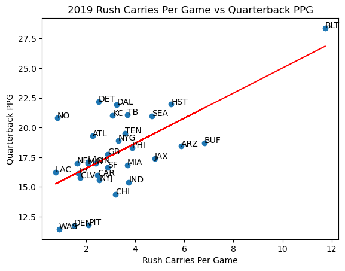

```python
plt.scatter(qb_2019_df['rushCarriesPg'], qb_2019_df['fantasyPpg'])
slope, intercept = np.polyfit(qb_2019_df['rushCarriesPg'], qb_2019_df['fantasyPpg'], 1)
plt.plot(qb_2019_df['rushCarriesPg'], intercept + slope * qb_2019_df['rushCarriesPg'], 'red')
plt.xlabel("Rush Carries Per Game")
plt.ylabel("Quarterback PPG")
plt.title("2019 Rush Carries Per Game vs Quarterback PPG")
for index in qb_2019_df.index:
    row = qb_2019_df.loc[index]
    plt.text(row['rushCarriesPg'], row['fantasyPpg'], row['team'])
plt.show()
```

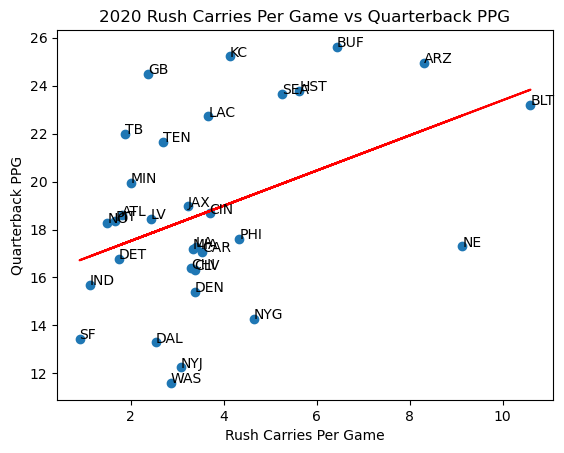

```python
plt.scatter(qb_2020_df['rushCarriesPg'], qb_2020_df['fantasyPpg'])
slope, intercept = np.polyfit(qb_2020_df['rushCarriesPg'], qb_2020_df['fantasyPpg'], 1)
plt.plot(qb_2020_df['rushCarriesPg'], intercept + slope * qb_2020_df['rushCarriesPg'], 'red')
plt.xlabel("Rush Carries Per Game")
plt.ylabel("Quarterback PPG")
plt.title("2020 Rush Carries Per Game vs Quarterback PPG")
for index in qb_2020_df.index:
    row = qb_2020_df.loc[index]
    plt.text(row['rushCarriesPg'], row['fantasyPpg'], row['team'])
plt.show()
```

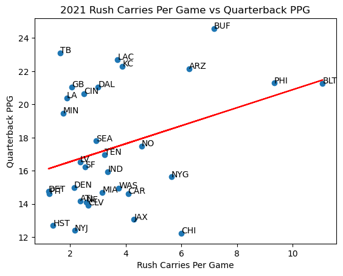

```python
plt.scatter(qb_2021_df['rushCarriesPg'], qb_2021_df['fantasyPpg'])
slope, intercept = np.polyfit(qb_2021_df['rushCarriesPg'], qb_2021_df['fantasyPpg'], 1)
plt.plot(qb_2021_df['rushCarriesPg'], intercept + slope * qb_2021_df['rushCarriesPg'], 'red')
plt.xlabel("Rush Carries Per Game")
plt.ylabel("Quarterback PPG")
plt.title("2021 Rush Carries Per Game vs Quarterback PPG")
for index in qb_2021_df.index:
    row = qb_2021_df.loc[index]
    plt.text(row['rushCarriesPg'], row['fantasyPpg'], row['team'])
plt.show()
```

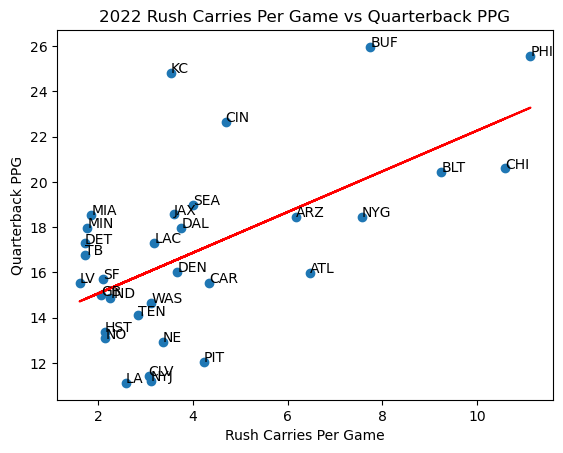

```python
plt.scatter(qb_2022_df['rushCarriesPg'], qb_2022_df['fantasyPpg'])
slope, intercept = np.polyfit(qb_2022_df['rushCarriesPg'], qb_2022_df['fantasyPpg'], 1)
plt.plot(qb_2022_df['rushCarriesPg'], intercept + slope * qb_2022_df['rushCarriesPg'], 'red')
plt.xlabel("Rush Carries Per Game")
plt.ylabel("Quarterback PPG")
plt.title("2022 Rush Carries Per Game vs Quarterback PPG")
for index in qb_2022_df.index:
    row = qb_2022_df.loc[index]
    plt.text(row['rushCarriesPg'], row['fantasyPpg'], row['team'])
plt.show()
```

The plots above show the relationship between a quarterbacks running ability and their fantasy production. As we can see, other than 2018, there is a strong relationship between a quarterbacks rushing attempts and their fantasy production.

For our last analysis we are going to look at how a running backs involvement in the passing game impacts their fantasy production. Running backs mainly get handed the ball in the backfield and run the ball to try and steady consistent yardage gains. But runningbacks can also catch passes out of the backfield or even lined up at another spot on the field. The statistics we will use for this analysis are receiveing targets and fantasy points per game. To see if there is any correlation between a running back that is used more in the passing game and their fantasy production.

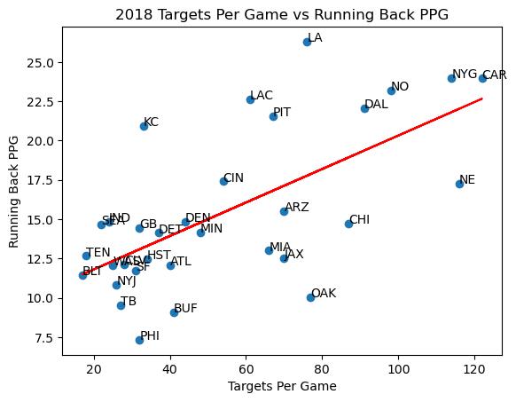

```python
plt.scatter(rb_2018_df['recTarg'], rb_2018_df['fantasyPpg'])
slope, intercept = np.polyfit(rb_2018_df['recTarg'], rb_2018_df['fantasyPpg'], 1)
plt.plot(rb_2018_df['recTarg'], intercept + slope * rb_2018_df['recTarg'], 'red')
plt.xlabel("Targets Per Game")
plt.ylabel("Running Back PPG")
plt.title("2018 Targets Per Game vs Running Back PPG")
for index in rb_2018_df.index:
    row = rb_2018_df.loc[index]
    plt.text(row['recTarg'], row['fantasyPpg'], row['team'])
plt.show()
```

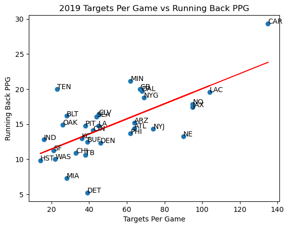

```python
plt.scatter(rb_2019_df['recTarg'], rb_2019_df['fantasyPpg'])
slope, intercept = np.polyfit(rb_2019_df['recTarg'], rb_2019_df['fantasyPpg'], 1)
plt.plot(rb_2019_df['recTarg'], intercept + slope * rb_2019_df['recTarg'], 'red')
plt.xlabel("Targets Per Game")
plt.ylabel("Running Back PPG")
plt.title("2019 Targets Per Game vs Running Back PPG")
for index in rb_2019_df.index:
    row = rb_2019_df.loc[index]
    plt.text(row['recTarg'], row['fantasyPpg'], row['team'])
plt.show()
```

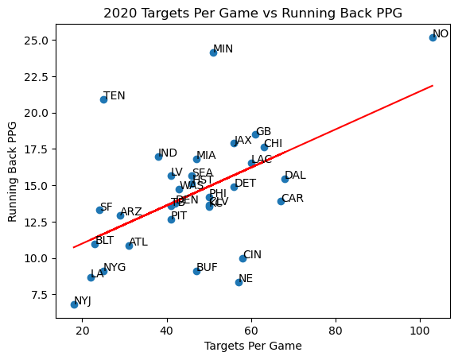

```python
plt.scatter(rb_2020_df['recTarg'], rb_2020_df['fantasyPpg'])
slope, intercept = np.polyfit(rb_2020_df['recTarg'], rb_2020_df['fantasyPpg'], 1)
plt.plot(rb_2020_df['recTarg'], intercept + slope * rb_2020_df['recTarg'], 'red')
plt.xlabel("Targets Per Game")
plt.ylabel("Running Back PPG")
plt.title("2020 Targets Per Game vs Running Back PPG")
for index in rb_2020_df.index:
    row = rb_2020_df.loc[index]
    plt.text(row['recTarg'], row['fantasyPpg'], row['team'])
plt.show()
```

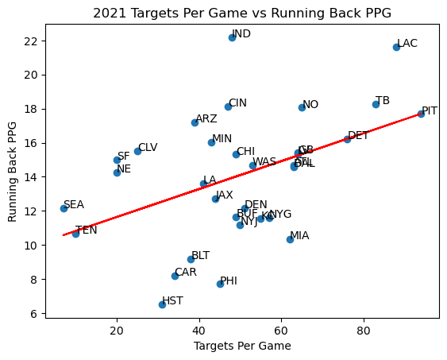

```python
plt.scatter(rb_2021_df['recTarg'], rb_2021_df['fantasyPpg'])
slope, intercept = np.polyfit(rb_2021_df['recTarg'], rb_2021_df['fantasyPpg'], 1)
plt.plot(rb_2021_df['recTarg'], intercept + slope * rb_2021_df['recTarg'], 'red')
plt.xlabel("Targets Per Game")
plt.ylabel("Running Back PPG")
plt.title("2021 Targets Per Game vs Running Back PPG")
for index in rb_2021_df.index:
    row = rb_2021_df.loc[index]
    plt.text(row['recTarg'], row['fantasyPpg'], row['team'])
plt.show()
```

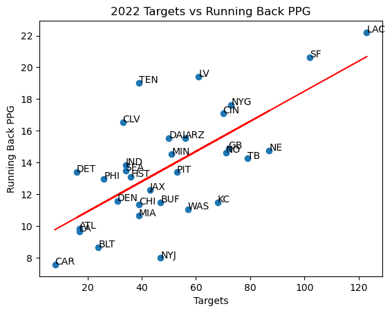

```python
plt.scatter(rb_2022_df['recTarg'], rb_2022_df['fantasyPpg'])
slope, intercept = np.polyfit(rb_2022_df['recTarg'], rb_2022_df['fantasyPpg'], 1)
plt.plot(rb_2022_df['recTarg'], intercept + slope * rb_2022_df['recTarg'], 'red')
plt.xlabel("Targets")
plt.ylabel("Running Back PPG")
plt.title("2022 Targets vs Running Back PPG")
for index in rb_2022_df.index:
    row = rb_2022_df.loc[index]
    plt.text(row['recTarg'], row['fantasyPpg'], row['team'])
plt.show()
```

The plots above show the relationship between a running backs targets and their fantasy points per game. As we can see again the more targets a receiver gets the more fantasy points they are likely to score.

## Models

Now that we have seen how different statistical categories can affect a positions fantasy production. We are going to look at a full ordinary least squares regression model. This will allow us to make predictions on fantasy production based on the given stats and we will be able to see which stats have strong correlations.

The first model we are going to look at is how can a quarterbacks production predict a wide receivers production.

```python
qb_to_pc_full = pd.concat([qb_to_pc_2018, qb_to_pc_2019, qb_to_pc_2020, qb_to_pc_2021, qb_to_pc_2022])
```

```python
pass_catcher_model = smf.ols(formula='fantasyPpg_y ~ fantasyPpg_x', data=qb_to_pc_full).fit()
```

```python
pass_catcher_model.summary()
```

OLS Regression Results

| Dep. Variable: | fantasyPpg_y | R-squared: | 0.231 |
| --- | --- | --- | --- |
| Model: | OLS | Adj. R-squared: | 0.226 |
| Method: | Least Squares | F-statistic: | 47.41 |
| Date: | Mon, 21 Aug 2023 | Prob (F-statistic): | 1.28e-10 |
| Time: | 01:53:58 | Log-Likelihood: | -413.76 |
| No. Observations: | 160 | AIC: | 831.5 |
| Df Residuals: | 158 | BIC: | 837.7 |
| Df Model: | 1 |  |  |
| Covariance Type: | nonrobust |  |  |

|  | coef | std err | t | P>\|t\| | [0.025 | 0.975] |
| --- | --- | --- | --- | --- | --- | --- |
| Intercept | 6.4881 | 1.244 | 5.214 | 0.000 | 4.031 | 8.946 |
| fantasyPpg_x | 0.4721 | 0.069 | 6.885 | 0.000 | 0.337 | 0.608 |

| Omnibus: | 4.570 | Durbin-Watson: | 1.003 |
| --- | --- | --- | --- |
| Prob(Omnibus): | 0.102 | Jarque-Bera (JB): | 4.530 |
| Skew: | 0.258 | Prob(JB): | 0.104 |
| Kurtosis: | 3.643 | Cond. No. | 88.6 |

Notes:  
[1] Standard Errors assume that the covariance matrix of the errors is correctly specified.

```python
m = pass_catcher_model.params['fantasyPpg_x']
b = pass_catcher_model.params['Intercept']
x_values = np.array([10.0, 27.5])
```

[figure not shown]

```python
plt.scatter(qb_to_pc_full['fantasyPpg_x'], qb_to_pc_full['fantasyPpg_y'])
plt.plot(x_values, b + m * x_values, 'red')
plt.xlabel("Quarterback PPG")
plt.ylabel("Running Back PPG")
plt.title("2018-2022 Quarterback PPG vs Running Back PPG")
plt.show()
```

The model above shows the ordinary least squares regression for the relationship between a quarterbacks fantasy production and the teams top wide recevier production. With this model we could predict relatively how well we can expect a teams top wide receiver to do based on their quarterback. For the NFL season this year for example I expect a receiver like Chris Olave who plays for the New Orleans Saints to take a jump in fantasy production since his quarterback has improved from Andy Dalton to Derek Carr. An example of a receiver whose production I would expect to go down is Mike Evans of the Tampa Bay Buccaneers since his quarterback has regressed from Tom Brady to Baker Mayfield. Since the p-value of the coefficients in the model above are less than 0.05 we can reject the null hypothesis of no relationship between a quarterback's fantasy ppg and their top pass catcher's fantasy ppg. This allows us to conclude that there is a correlation between these statistics as well.

Now we are going to look at a running backs production based on the quarterbacks production and the amount of times that running back is targeted in the pass game.

```python
qb_to_rb_2018 = pd.merge(qb_to_rb_2018, rb_2018_df, on='team', how='inner')
qb_to_rb_2019 = pd.merge(qb_to_rb_2019, rb_2019_df, on='team', how='inner')
qb_to_rb_2020 = pd.merge(qb_to_rb_2020, rb_2020_df, on='team', how='inner')
qb_to_rb_2021 = pd.merge(qb_to_rb_2021, rb_2021_df, on='team', how='inner')
qb_to_rb_2022 = pd.merge(qb_to_rb_2022, rb_2022_df, on='team', how='inner')
```

```python
qb_to_rb_full = pd.concat([qb_to_rb_2018, qb_to_rb_2019, qb_to_rb_2020, qb_to_rb_2021, qb_to_rb_2022])
```

```python
qb_to_rb_full
```

|  | player_x | team | fantasyPpg_x | player_y | fantasyPpg_y | player | games | position | recTarg | recRec | rzRecTarg | ezRecTarg | rushCarries | rzRushCarries | i5RushCarries | fantasyPts | fantasyPpg |
| --- | --- | --- | --- | --- | --- | --- | --- | --- | --- | --- | --- | --- | --- | --- | --- | --- | --- |
| 0 | Jared Goff | LA | 20.393750 | Todd Gurley II | 26.292857 | Todd Gurley II | 14 | RB | 76 | 59 | 19 | 4 | 256 | 64 | 22 | 368.1 | 26.292857 |
| 1 | Eli Manning | NYG | 15.812500 | Saquon Barkley | 23.987500 | Saquon Barkley | 16 | RB | 114 | 91 | 16 | 2 | 261 | 50 | 18 | 383.8 | 23.987500 |
| 2 | Cam Newton | CAR | 20.828571 | Christian McCaffrey | 23.950000 | Christian McCaffrey | 16 | RB | 122 | 108 | 19 | 2 | 219 | 46 | 16 | 383.2 | 23.950000 |
| 3 | Drew Brees | NO | 20.593333 | Alvin Kamara | 23.213333 | Alvin Kamara | 15 | RB | 98 | 81 | 25 | 2 | 194 | 51 | 16 | 348.2 | 23.213333 |
| 4 | Philip Rivers | LAC | 18.062500 | Melvin Gordon III | 22.625000 | Melvin Gordon III | 12 | RB | 61 | 50 | 10 | 2 | 175 | 25 | 5 | 271.5 | 22.625000 |
| ... | ... | ... | ... | ... | ... | ... | ... | ... | ... | ... | ... | ... | ... | ... | ... | ... | ... |
| 22 | Taylor Heinicke | WAS | 14.666667 | Antonio Gibson | 11.060000 | Antonio Gibson | 15 | RB | 57 | 46 | 7 | 2 | 149 | 26 | 10 | 165.9 | 11.060000 |
| 23 | Tua Tagovailoa | MIA | 18.530769 | Raheem Mostert | 10.650000 | Raheem Mostert | 16 | RB | 39 | 31 | 10 | 1 | 181 | 21 | 5 | 170.4 | 10.650000 |
| 24 | Marcus Mariota | ATL | 15.969231 | Tyler Allgeier | 9.837500 | Tyler Allgeier | 16 | RB | 17 | 16 | 0 | 0 | 210 | 39 | 10 | 157.4 | 9.837500 |
| 25 | Zach Wilson | NYJ | 11.188889 | Michael Carter | 8.000000 | Michael Carter | 16 | RB | 47 | 41 | 5 | 1 | 114 | 20 | 4 | 128.0 | 8.000000 |
| 26 | Sam Darnold | CAR | 15.550000 | D'Onta Foreman | 7.582353 | D'Onta Foreman | 17 | RB | 8 | 5 | 1 | 0 | 203 | 35 | 10 | 128.9 | 7.582353 |

155 rows × 17 columns

```python
running_back_model = smf.ols(formula='fantasyPpg_y ~ recTarg + fantasyPpg_x', data=qb_to_rb_full).fit()
```

```python
running_back_model.summary()
```

OLS Regression Results

| Dep. Variable: | fantasyPpg_y | R-squared: | 0.386 |
| --- | --- | --- | --- |
| Model: | OLS | Adj. R-squared: | 0.378 |
| Method: | Least Squares | F-statistic: | 47.71 |
| Date: | Mon, 21 Aug 2023 | Prob (F-statistic): | 8.30e-17 |
| Time: | 01:53:58 | Log-Likelihood: | -406.16 |
| No. Observations: | 155 | AIC: | 818.3 |
| Df Residuals: | 152 | BIC: | 827.4 |
| Df Model: | 2 |  |  |
| Covariance Type: | nonrobust |  |  |

|  | coef | std err | t | P>\|t\| | [0.025 | 0.975] |
| --- | --- | --- | --- | --- | --- | --- |
| Intercept | 6.6306 | 1.428 | 4.643 | 0.000 | 3.809 | 9.452 |
| recTarg | 0.1023 | 0.011 | 9.442 | 0.000 | 0.081 | 0.124 |
| fantasyPpg_x | 0.1585 | 0.074 | 2.137 | 0.034 | 0.012 | 0.305 |

| Omnibus: | 2.460 | Durbin-Watson: | 1.070 |
| --- | --- | --- | --- |
| Prob(Omnibus): | 0.292 | Jarque-Bera (JB): | 1.990 |
| Skew: | 0.237 | Prob(JB): | 0.370 |
| Kurtosis: | 3.287 | Cond. No. | 312. |

Notes:  
[1] Standard Errors assume that the covariance matrix of the errors is correctly specified.

```
[<mpl_toolkits.mplot3d.art3d.Line3D at 0xffff5bb04450>]
```

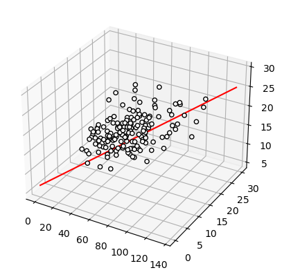

```python
fig = plt.figure()
ax = fig.add_subplot(111, projection='3d')
ax.scatter(qb_to_rb_full['recTarg'], qb_to_rb_full['fantasyPpg_x'], qb_to_rb_full['fantasyPpg_y'], color='black', alpha=1.0, facecolor='white')

intercept = running_back_model.params['Intercept']
theta_1 = running_back_model.params['recTarg']
theta_2 = running_back_model.params['fantasyPpg_x']
x_values = np.array([0, 135])
y_values = np.array([0, 30])

ax.plot(x_values, y_values, intercept + (theta_1 * x_values) + (theta_2 * y_values), 'red')
```

The model above shows the ordinary least squares regression for the relationship between a quarterbacks fantasy production, and the teams top running back's targets and production. With this model we could predict relatively how well we can expect a teams top running back to do based on their quarterback and targets that they get in the passing game. For the NFL season this year for example I expect a receiver like Alvin Kamara who plays for the New Orleans Saints to take a jump in fantasy production since his quarterback has improved and he plays in a system that targets running backs in the pass game. An example of a running back whose production I would expect to go down is Josh Jacobs of the Las Vegas Raiders since his quarterback has regressed and his new quarterback does not have a history of throwing to the running back much in the pass game. Since the p-value of the coefficients in the running back model above are less than 0.05 we can reject the null hypothesis of no relationship between a running back's production and their targets along with their quarterbacks production. Again this allows us to conclude that there is a correlation between these statistics.

For our last model we are going to look at a quarterbacks production based on the grade of their offensive line and their running ability

```python
qb_to_ol_2018 = pd.merge(qb_2018_df, ol_grades_df[['team', '2018']], on='team', how='inner')
qb_to_ol_2019 = pd.merge(qb_2019_df, ol_grades_df[['team', '2019']], on='team', how='inner')
qb_to_ol_2020 = pd.merge(qb_2020_df, ol_grades_df[['team', '2020']], on='team', how='inner')
qb_to_ol_2021 = pd.merge(qb_2021_df, ol_grades_df[['team', '2021']], on='team', how='inner')
qb_to_ol_2022 = pd.merge(qb_2022_df, ol_grades_df[['team', '2022']], on='team', how='inner')
```

```python
qb_to_ol_2018.rename(columns = {'2018':'oline_grade'}, inplace = True)
qb_to_ol_2019.rename(columns = {'2019':'oline_grade'}, inplace = True)
qb_to_ol_2020.rename(columns = {'2020':'oline_grade'}, inplace = True)
qb_to_ol_2021.rename(columns = {'2021':'oline_grade'}, inplace = True)
qb_to_ol_2022.rename(columns = {'2022':'oline_grade'}, inplace = True)
```

```python
qb_to_ol_full = pd.concat([qb_to_ol_2018, qb_to_ol_2019, qb_to_ol_2020, qb_to_ol_2021, qb_to_ol_2022])
```

```python
qb_to_ol_full
```

|  | player | team | games | att | comp | ezAtt | rushCarries | rzRushCarries | i5RushCarries | fantasyPts | fantasyPpg | rushCarriesPg | oline_grade |
| --- | --- | --- | --- | --- | --- | --- | --- | --- | --- | --- | --- | --- | --- |
| 0 | Patrick Mahomes | KC | 16 | 580 | 383 | 43 | 60 | 15 | 6 | 431.1 | 26.943750 | 3.750000 | 81.8 |
| 1 | Matt Ryan | ATL | 16 | 608 | 422 | 34 | 34 | 8 | 2 | 360.5 | 22.531250 | 2.125000 | 78.2 |
| 2 | Ben Roethlisberger | PIT | 16 | 675 | 452 | 50 | 31 | 5 | 3 | 353.0 | 22.062500 | 1.937500 | 87.3 |
| 3 | Deshaun Watson | HST | 16 | 505 | 345 | 47 | 100 | 22 | 9 | 346.6 | 21.662500 | 6.250000 | 69.8 |
| 4 | Andrew Luck | IND | 16 | 639 | 430 | 48 | 46 | 7 | 1 | 339.5 | 21.218750 | 2.875000 | 79.8 |
| ... | ... | ... | ... | ... | ... | ... | ... | ... | ... | ... | ... | ... | ... |
| 27 | Mac Jones | NE | 14 | 442 | 288 | 17 | 47 | 9 | 1 | 181.1 | 12.935714 | 3.357143 | 72.5 |
| 28 | Kenny Pickett | PIT | 13 | 389 | 245 | 25 | 55 | 11 | 6 | 156.7 | 12.053846 | 4.230769 | 69.5 |
| 29 | Jacoby Brissett | CLV | 16 | 369 | 236 | 30 | 49 | 11 | 2 | 182.6 | 11.412500 | 3.062500 | 73.4 |
| 30 | Zach Wilson | NYJ | 9 | 242 | 132 | 10 | 28 | 8 | 3 | 100.7 | 11.188889 | 3.111111 | 59.2 |
| 31 | Baker Mayfield | LA | 12 | 335 | 201 | 11 | 31 | 7 | 0 | 133.4 | 11.116667 | 2.583333 | 62.0 |

160 rows × 13 columns

```python
quarterback_model = smf.ols(formula='fantasyPpg ~ oline_grade + rushCarriesPg', data=qb_to_ol_full).fit()
```

```python
quarterback_model.summary()
```

OLS Regression Results

| Dep. Variable: | fantasyPpg | R-squared: | 0.220 |
| --- | --- | --- | --- |
| Model: | OLS | Adj. R-squared: | 0.210 |
| Method: | Least Squares | F-statistic: | 22.13 |
| Date: | Mon, 21 Aug 2023 | Prob (F-statistic): | 3.41e-09 |
| Time: | 01:53:58 | Log-Likelihood: | -417.68 |
| No. Observations: | 160 | AIC: | 841.4 |
| Df Residuals: | 157 | BIC: | 850.6 |
| Df Model: | 2 |  |  |
| Covariance Type: | nonrobust |  |  |

|  | coef | std err | t | P>\|t\| | [0.025 | 0.975] |
| --- | --- | --- | --- | --- | --- | --- |
| Intercept | 7.9563 | 2.118 | 3.757 | 0.000 | 3.773 | 12.140 |
| oline_grade | 0.1113 | 0.031 | 3.617 | 0.000 | 0.051 | 0.172 |
| rushCarriesPg | 0.5834 | 0.119 | 4.916 | 0.000 | 0.349 | 0.818 |

| Omnibus: | 0.617 | Durbin-Watson: | 0.666 |
| --- | --- | --- | --- |
| Prob(Omnibus): | 0.735 | Jarque-Bera (JB): | 0.333 |
| Skew: | -0.083 | Prob(JB): | 0.847 |
| Kurtosis: | 3.149 | Cond. No. | 563. |

Notes:  
[1] Standard Errors assume that the covariance matrix of the errors is correctly specified.

```
[<mpl_toolkits.mplot3d.art3d.Line3D at 0xffff5b8d1450>]
```

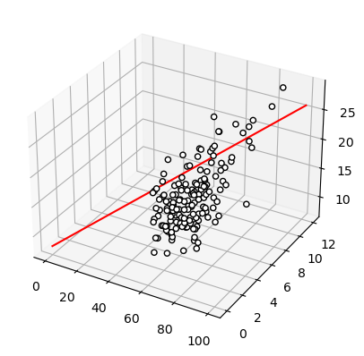

```python
fig = plt.figure()
ax = fig.add_subplot(111, projection='3d')
ax.scatter(qb_to_ol_full['oline_grade'], qb_to_ol_full['rushCarriesPg'], qb_to_ol_full['fantasyPpg'], color='black', alpha=1.0, facecolor='white')

intercept = quarterback_model.params['Intercept']
theta_1 = quarterback_model.params['oline_grade']
theta_2 = quarterback_model.params['rushCarriesPg']
x_values = np.array([0, 100])
y_values = np.array([0, 12])

ax.plot(x_values, y_values, intercept + (theta_1 * x_values) + (theta_2 * y_values), 'red')
```

The model above shows the ordinary least squares regression for the relationship between a quarterbacks fantasy production and their offensive line and runnning abilities. With this model we could predict relatively how well we can expect a quarterback to do based on their offensive line and their expected carries. For the NFL season this year for example I expect a Justin Fields who plays for the Chicago Bears to improve his fantasy production since his offensive line has improved and he showed flashes last year of exceptional running ability. An example of a quarterback whose production I would expect to decrease is Aaron Rodgers of the New York Jets since he has gone from a good offensive line in Green Bay to a notoriously bad offensive line in New York, coupled with his lack of a running threat. Since the p-value of the coefficients in the quarterback model above are less than 0.05 we can reject the null hypothesis of no relationship between a quarterback's production and their offensive line along with their running ability. Once again this allows us to conclude that there is a correlation between these statistics.

## Conclusions

As we can see from the data above we can make some good predictions about how a football players will perform in fantasy points this upcoming season. Through regression analysis, visualization and hypothesis testing we were able to draw the conclusions that a pass catcher will have good fantasy football production this NFL season if they have a good quarterback throwing them the ball. If a wide recevier switched teams this offseason and their quarterback has improved we can expect their fantasy production to go up, and vice versa if a pass catcher switched teams to a worse quarterback. When looking at rookie pass catchers this year we can expect the receivers that went to teams with a good quarterback to have better production. In addition to that we can make the conclusion that a running back will be likely to have a better fantasy season if again they have a good quarterback that includes them more in the passing game. Having a good quarterback allows for more opportunities for the running back to get carries and allows for more scoring opportunities. Involving them in the passsing game makes them more dynamic and more difficult to stop on defense. We can expect a rookie like Jahmyr Gibbs to have a good seasom given he has a relatively good quarterback and has good pass catching skills. Finally we can come to the conclusion that a quarterback will have a good fantasy season if they have a good offensive line in front of them and they have good running ability. If a quarterback goes to a new team with a better offensive line or better offensive linemen are brought into their team we can expect their fantasy production to increase and vice versa if they have a worse offensive line. Out of all the rookie quarterbacks this year I expect Anthony Richardson to have the best fantasy season given that he has an average offensive line and has great running ability, along with an offensive system that will give him plenty of rushing opportunities. I will use these conclusions in my leagues this year and expect to perform very well and hopefully win some leagues.